# Analysis for Reena

# 1 Setup

## 1.1 Load data

```r
Turnout = read.csv ("http://www.sfu.ca/~sweldon/Final.csv")
DT::datatable(Turnout, options = list(scrollX = TRUE)) #don't include this line - this is just to visualize the table
```

|  | country | turnout | elec.year | compulsory | elec.type | democ.type | bicameral | DM | ENPP | competitiveness | years.democ | corrupt | educ | pop |
| --- | --- | --- | --- | --- | --- | --- | --- | --- | --- | --- | --- | --- | --- | --- |
| 1 | Andorra | 81.64 | 2001 | No | Mixed | Parliamentary | Bicameral | 2 | 2.6 | 46.4 |  |  |  | 67.2 |
| 2 | Australia | 94.85 | 2001 | Enforced | Majoritarian | Parliamentary | Bicameral | 1 | 3.46 | 62.2 | 70 | 8.6 | 10.922 | 18888 |
| 3 | Austria | 84.27 | 2002 | No | Proportional | Parliamentary | Bicameral | 4.26 | 3.82 | 57.7 | 46 | 7.8 | 8.354 | 8211 |
| 4 | Bahamas | 90.03 | 2002 | No | Majoritarian | Parliamentary | Bicameral | 1 |  | 49.2 | 28 |  |  | 305.68 |
| 5 | Barbados | 56.88 | 2003 | No | Majoritarian | Parliamentary | Bicameral | 1 | 1.84 | 35 | 35 | 7.3 | 8.732 | 276.66 |
| 6 | Belgium | 91.63 | 2003 | Enforced | Proportional | Parliamentary | Bicameral | 7.5 | 10.29 | 70 | 70 | 7.1 | 9.338 | 10281.55 |
| 7 | Belize | 79.52 | 2003 | No | Majoritarian | Parliamentary | Bicameral | 1 | 1.98 | 40.7 | 19 | 4.5 |  | 254.4 |
| 8 | Benin | 55.9 | 2003 | No | Proportional | Presidential | Unicameral | 3.5 | 3.91 | 32.9 | 9 | 3.2 | 2.335 | 6099 |
| 9 | Bolivia | 72.06 | 2002 | Not Enforced | Mixed | Presidential | Bicameral | 1 | 5.92 | 70 | 15 | 2.2 | 5.579 | 8333 |
| 10 | Bulgaria | 66.63 | 2001 | No | Proportional | Parliamentary | Unicameral | 7.74 | 3.02 | 50 | 10 | 4 |  | 8225 |

[output cut: 66 more lines]

## 1.2 Requirements

- Univariate Analyses (especially for the Dependent Variable).
- Bivariate Analyses
- Multiple Regression
- Robustness Checks for outliers and influence points
- Correctly run all statistical analyses, including at least 3 different types of bivariate analyses (remember there are 4 basic types:
  - T-Test
  - Chi-Square
  - ANOVA
  - Pearson’s R correlation coefficient

## 1.3 The hypothesies to test:

- Education plays a role in voter turnout because the more educated one is the more likely one will be politically informed and involved.
- Corruption effects voter turnout because the more corrupt a country is the less likely the election will be legitimate resulting in less voter turnout
- years.democ: Due to the the longevity of democracy the value that people place on it has depreciated which weakens voter turnout.

**But before I do this I’m going to look at the turnout variable:**

## 1.4 Distribution of Turnout and how Canada lies in the spectrum

### 1.4.1 Some numbers of turnout

```r
summary(Turnout$turnout)
```

```
##    Min. 1st Qu.  Median    Mean 3rd Qu.    Max.
##   21.58   60.28   69.53   70.13   81.39   98.04
```

Canada’s turnout

```r
subset(Turnout, country == "Canada")$turnout #Canada's turnout
```

```
## [1] 61.18
```

Looks like Canada is below the mean and median - almost as low as the 1st quartile

### 1.4.2 Plot

The vertical line represents Canada

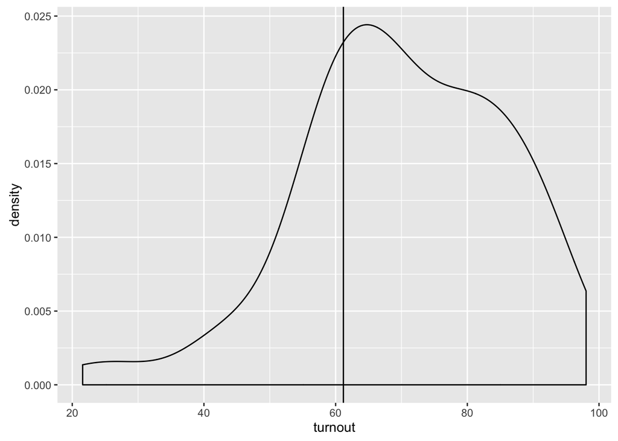

```r
ggplot(Turnout, aes(turnout)) +
  geom_density() +
  geom_vline(xintercept = 61.18) #61.18 number from the data frame
```

The turnout numbers are skewed to the left - not a normal distribution

# 2 Effect of education on turnout

**A country with a population who has higher education will result in a higher voter turnout**

Column name is `educ`

## 2.1 Univariate analysis

Line represents where Canada is

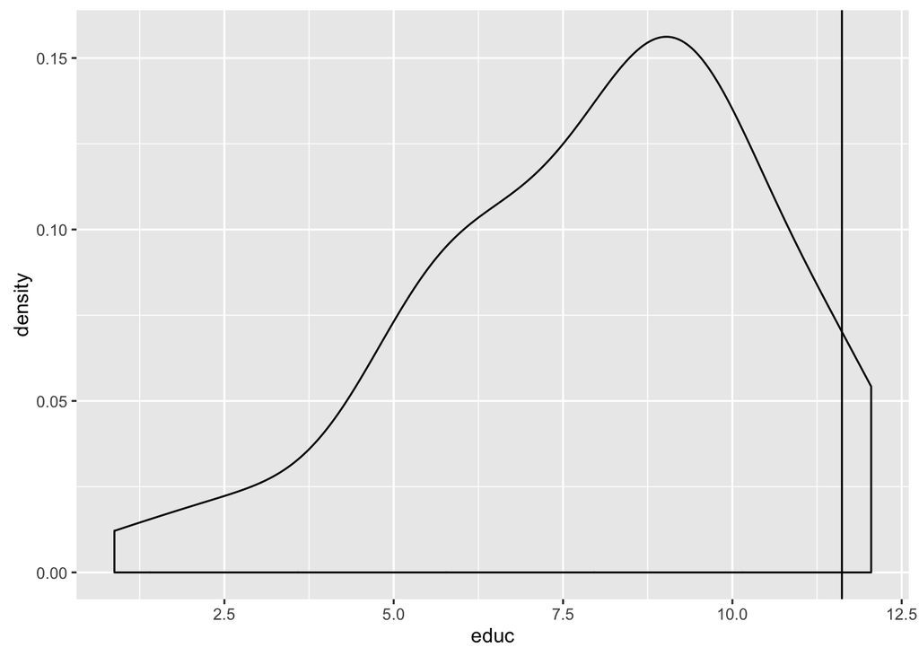

```r
ggplot(Turnout, aes(educ)) +
  geom_density() +
  geom_vline(xintercept = 11.617)
```

## 2.2 Bivariate analysis

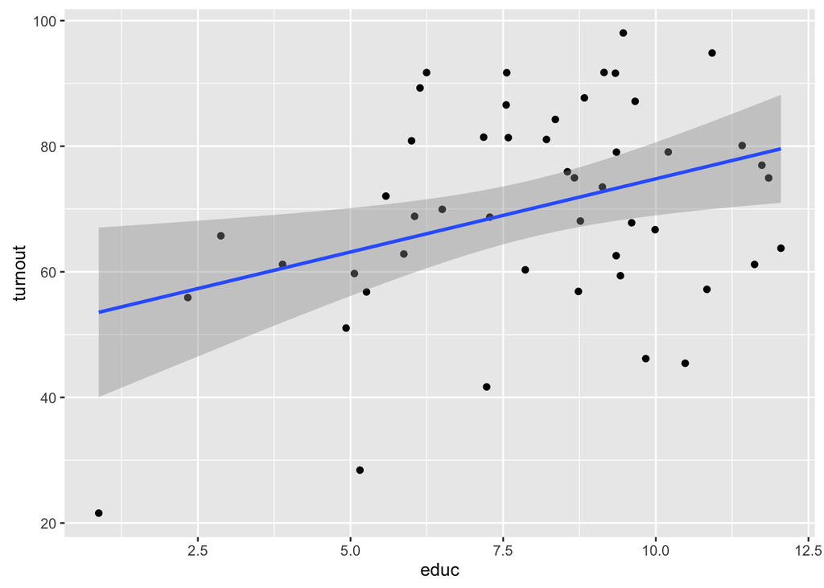

```r
ggplot(Turnout, aes(educ, turnout)) +
  geom_point() +
  geom_smooth(method = "lm")
```

Observation: seems like there’s a relationship

### 2.2.1 Statistical test - R correlation

- Null hypothesis: true correlation is equal to 0
- Alternate hypothesis: true correlation is not equal to 0

```r
cor.test(Turnout$educ, Turnout$turnout, use = "complete")
```

```
##
##  Pearson's product-moment correlation
##
## data:  Turnout$educ and Turnout$turnout
## t = 2.6152, df = 47, p-value = 0.01195
## alternative hypothesis: true correlation is not equal to 0
## 95 percent confidence interval:
##  0.08359762 0.57953020
## sample estimates:
##       cor
## 0.3564158
```

Correlation value is `0.3564158` which is a weakly positive relationship, and the p-value of this correlation is 0.01195, so we are at least 95% confident that this correlation value is real

## 2.3 Conclusion

Looks like more education leads to higher voter turnout, but Canada is already doing well on that so nothing to recommend.

# 3 The effect of corruption on voting

**Corruption effects voter turnout because the more corrupt a country is the less likely the election will be legitimate resulting in less voter turnout**

The column name is `corrupt`

## 3.1 Univariate analysis

Line represets where Canada is

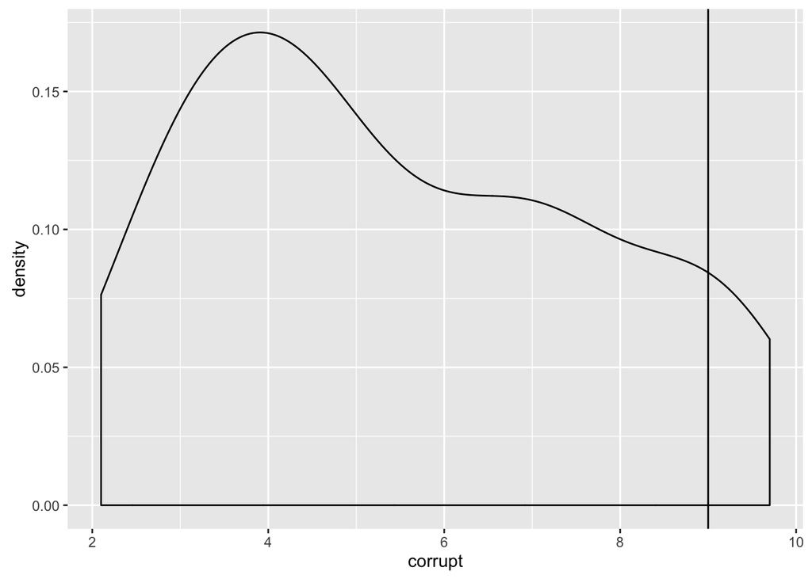

```r
ggplot(Turnout, aes(corrupt)) +
  geom_density() +
  geom_vline(xintercept = 9)
```

## 3.2 Bivariate analysis

Using scatterplot

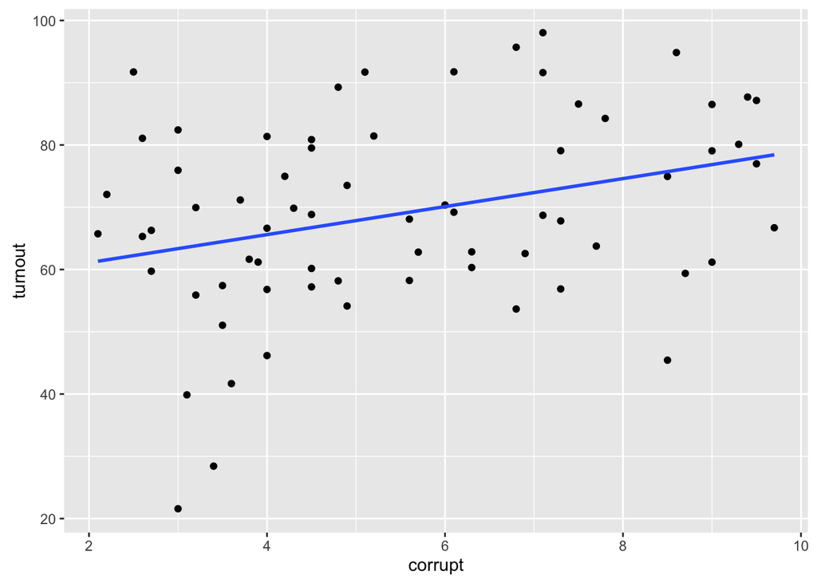

```r
ggplot(Turnout, aes(corrupt, turnout)) +
  geom_point() +
  geom_smooth(method = "lm", se=FALSE)
```

*Observation: looks like a really shitty correlation*

### 3.2.1 Statistical test - R correlation

- Null hypothesis: true correlation is equal to 0
- Alternate hypothesis: true correlation is not equal to 0

```r
cor.test(Turnout$corrupt, Turnout$turnout, use = "complete")
```

```
##
##  Pearson's product-moment correlation
##
## data:  Turnout$corrupt and Turnout$turnout
## t = 2.7572, df = 67, p-value = 0.007505
## alternative hypothesis: true correlation is not equal to 0
## 95 percent confidence interval:
##  0.08928646 0.51685197
## sample estimates:
##       cor
## 0.3192213
```

Correlation value is `0.3192213` which is weak positive relationship, and the p-value of this correlation is 0.007505, so can reject the null hypothesis that the true correlation is 0 and be confident that there is an actual correlation

## 3.3 Conclusion

```
corrupt: A continuous measure of the perceived level of political corruption in the country. Higher values mean lower perceived corruption.
```

Less corrupt countries (higher value) tend to have higher voter turnout. Canada’s corrpution score is 9, so Canada is already doing pretty well here and probably can’t improve.

# 4 The effect of `years.democ` on voting

**Due to the the longevity of democracy the value that people place on it has depreciated which weakens voter turnout.**

The column name is `years.democ`

## 4.1 Univariate analysis

Line represets where Canada is

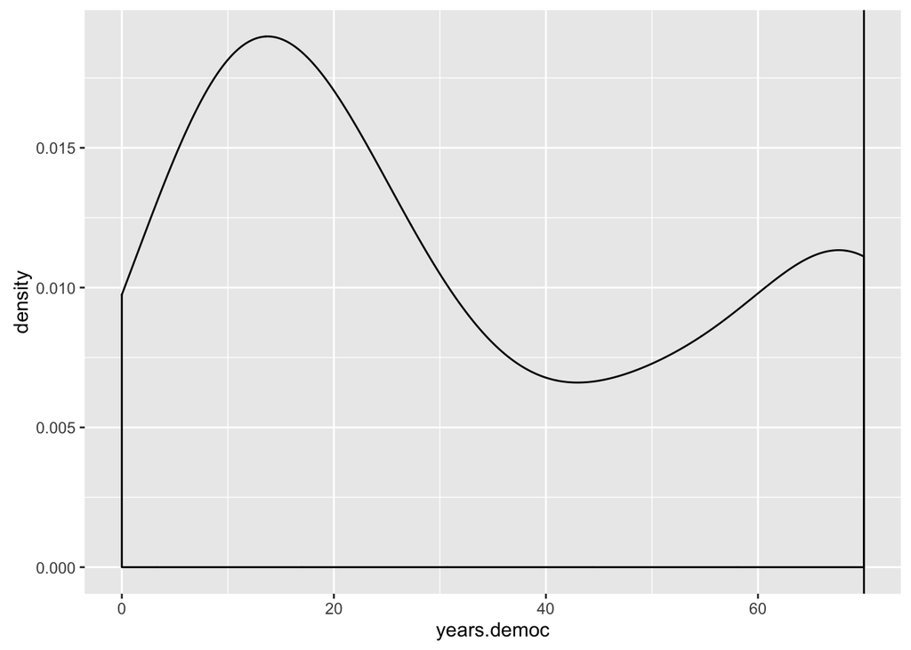

```r
ggplot(Turnout, aes(years.democ)) +
  geom_density() +
  geom_vline(xintercept = 70)
```

## 4.2 Bivariate analysis

Using scatterplot

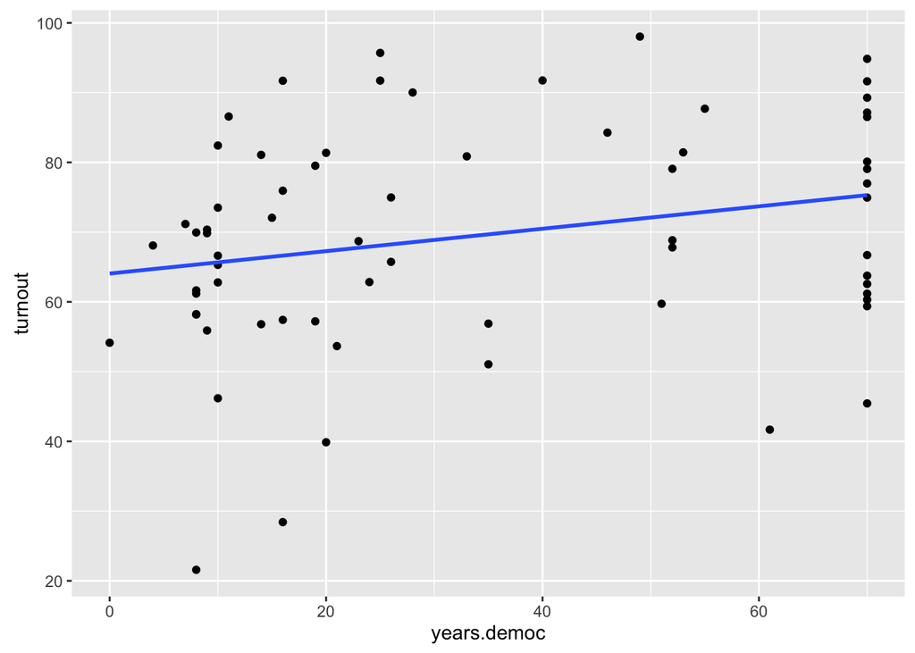

```r
ggplot(Turnout, aes(years.democ, turnout)) +
  geom_point() +
  geom_smooth(method = "lm", se=FALSE)
```

*Observation: looks like a really shitty correlation*

### 4.2.1 Statistical test - R correlation

- Null hypothesis: true correlation is equal to 0
- Alternate hypothesis: true correlation is not equal to 0

```r
cor.test(Turnout$years.democ, Turnout$turnout, use = "complete")
```

```
##
##  Pearson's product-moment correlation
##
## data:  Turnout$years.democ and Turnout$turnout
## t = 2.0666, df = 65, p-value = 0.04276
## alternative hypothesis: true correlation is not equal to 0
## 95 percent confidence interval:
##  0.008602562 0.461010513
## sample estimates:
##       cor
## 0.2482981
```

Correlation value is `0.2482981` which is weak positive relationship, and the p-value of this correlation is 0.04276, so can reject the null hypothesis that the true correlation is 0 and be confident that there is an actual correlation with at least 95% confidence.

## 4.3 Conclusion

Countries with longer years of democracy tend to have higher voter turnout. Canada has one of the highest years of democracy already do nothing for Canada to do here.

# 5 Multiple regression

Let’s run a multiple regression using all the columns

```r
turnout_complete = Turnout[complete.cases(Turnout),] #remove rows with missing data

model = lm(turnout ~ elec.year + elec.type + compulsory + competitiveness + democ.type + bicameral + DM + ENPP + years.democ + corrupt + educ + pop, turnout_complete)

summary(model)
```

```
##
## Call:
## lm(formula = turnout ~ elec.year + elec.type + compulsory + competitiveness +
##     democ.type + bicameral + DM + ENPP + years.democ + corrupt +
##     educ + pop, data = turnout_complete)
##
## Residuals:
##     Min      1Q  Median      3Q     Max
## -28.496  -6.268  -2.253   7.399  27.229
##
## Coefficients:
##                               Estimate Std. Error t value Pr(>|t|)
## (Intercept)                  1.835e+03  3.706e+03   0.495  0.62391
## elec.year                   -8.718e-01  1.855e+00  -0.470  0.64163
## elec.typeMixed               1.912e+01  7.747e+00   2.467  0.01933 *
## elec.typeProportional        1.137e+01  6.691e+00   1.700  0.09923 .
## compulsoryNo                -2.943e+01  8.751e+00  -3.363  0.00206 **
## compulsoryNot Enforced      -2.822e+01  1.047e+01  -2.696  0.01124 *
## competitiveness             -1.078e-01  2.894e-01  -0.373  0.71200
## democ.typePresidential      -1.455e+01  6.363e+00  -2.287  0.02918 *
## democ.typeSemi-Presidential -1.275e+01  7.259e+00  -1.757  0.08877 .
## bicameralUnicameral          2.509e+00  4.937e+00   0.508  0.61495
## DM                           6.363e-02  7.913e-02   0.804  0.42742
## ENPP                        -1.137e+00  1.595e+00  -0.713  0.48142
## years.democ                  9.444e-02  1.526e-01   0.619  0.54050
## corrupt                     -2.982e-01  2.148e+00  -0.139  0.89050
## educ                         9.818e-01  1.522e+00   0.645  0.52377
## pop                          2.262e-06  1.846e-05   0.123  0.90327
## ---
## Signif. codes:  0 '***' 0.001 '**' 0.01 '*' 0.05 '.' 0.1 ' ' 1
##
## Residual standard error: 14.56 on 31 degrees of freedom
## Multiple R-squared:  0.5028, Adjusted R-squared:  0.2623
## F-statistic:  2.09 on 15 and 31 DF,  p-value: 0.04051
```

Looks like `compulsoryNo` is highly significant in having lower voter turnout (t-value is negative = lower than expected, pvalue is 0.002 which makes it significant). So the model suggests that a country should have mandatory voting. Should check this

## 5.1 Checking `compulsory`

(because otherwise you don’t have any t-tests or ANOVA tests)

The column name is `compulsory`

### 5.1.1 Univariate analysis

Using a bar chart

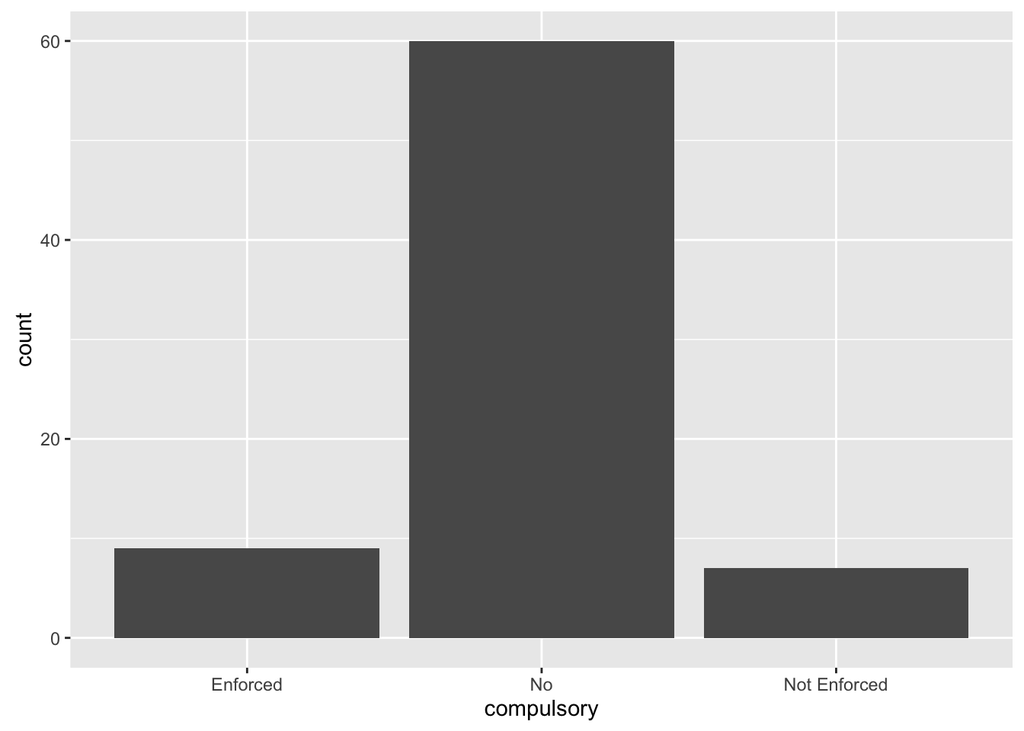

```r
ggplot(Turnout, aes(compulsory)) +
  geom_bar()
```

### 5.1.2 Bivariate analysis

#### 5.1.2.1 Plot

Using boxplot

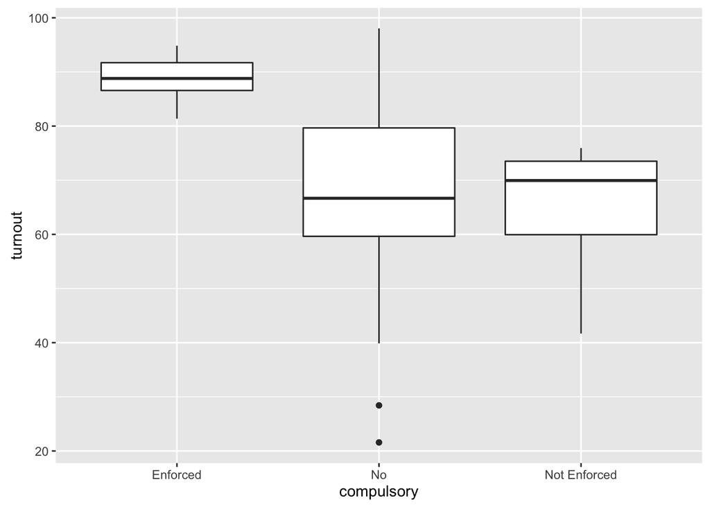

```r
ggplot(Turnout, aes(compulsory, turnout)) +
  geom_boxplot()
```

#### 5.1.2.2 Statistical test - ANOVA

- Null: there is no relationship between turnout and compulsory
- Alternate: there is a relationship between turnout and compulsory

```r
anova(lm(turnout ~ compulsory, Turnout))
```

```
## Analysis of Variance Table
##
## Response: turnout
##            Df  Sum Sq Mean Sq F value    Pr(>F)
## compulsory  2  3646.9  1823.5  9.2234 0.0002683 ***
## Residuals  73 14432.2   197.7
## ---
## Signif. codes:  0 '***' 0.001 '**' 0.01 '*' 0.05 '.' 0.1 ' ' 1
```

Pvalue is `0.0002683`, which is below the 0.05 threshold. Therefore, we can reject the null hypothesis and lend support for the alternative hypothesis: there is a relationship between compulsory and turnout

#### 5.1.2.3 Statistical test - T-test

*The difference here is that we are directly comparing two groups, whereas before we were comparing all groups*

- Null: countries with `Enforced` have same turnout as countries that are `Not enforced`
- Alternate: countries with `Not Enforced` have **different** turnout commpared to countries that are `Not enforced`

```r
turnout_notenforced = subset(Turnout, compulsory != "No")
t.test(turnout ~ compulsory, turnout_notenforced)
```

```
##
##  Welch Two Sample t-test
##
## data:  turnout by compulsory
## t = 4.6318, df = 6.8836, p-value = 0.0025
## alternative hypothesis: true difference in means is not equal to 0
## 95 percent confidence interval:
##  11.68233 36.22338
## sample estimates:
##     mean in group Enforced mean in group Not Enforced
##                   88.88000                   64.92714
```

Pvalue is `0.0025`, which is below the 0.05 threshold. Therefore, we can reject the null hypothesis and we can conclude that enforcing compulsory voting leads to higher voter turnout.

### 5.1.3 Conclusion

Countries should have compulsory voting to increase voter turnout. Also, countries with compulsory voting should enforce it to have a higher increase in voter turnout compared to unenforced. Canada does not have compulsory voting, so one might recommend that Canada makes voting compulsory and enforce it

## 5.2 Idenifying outliers/influence points

### 5.2.1 qqPlot

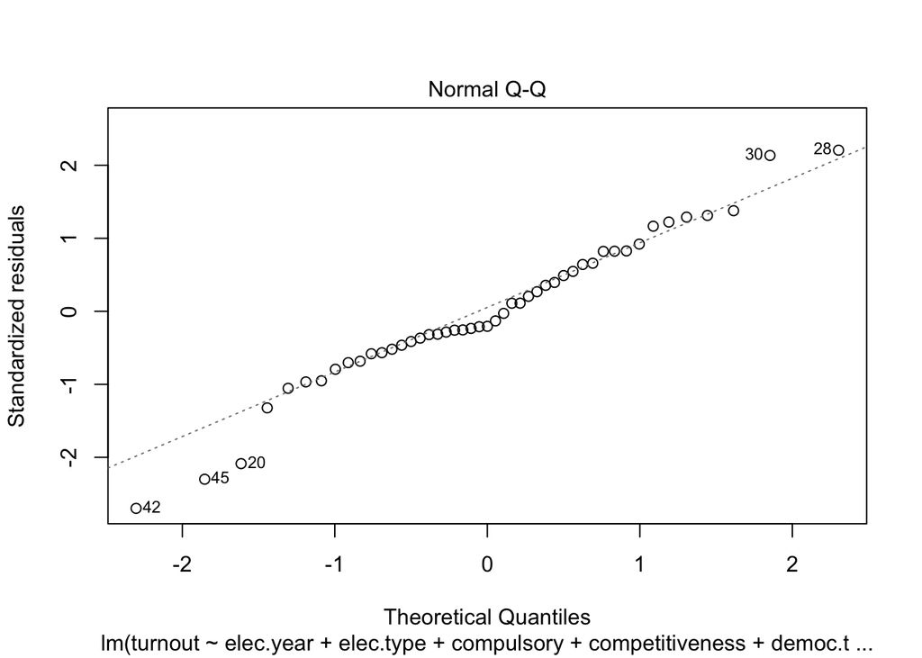

```r
plot(model, which = 2, id.n = 5)
```

### 5.2.2 Cook’s plot

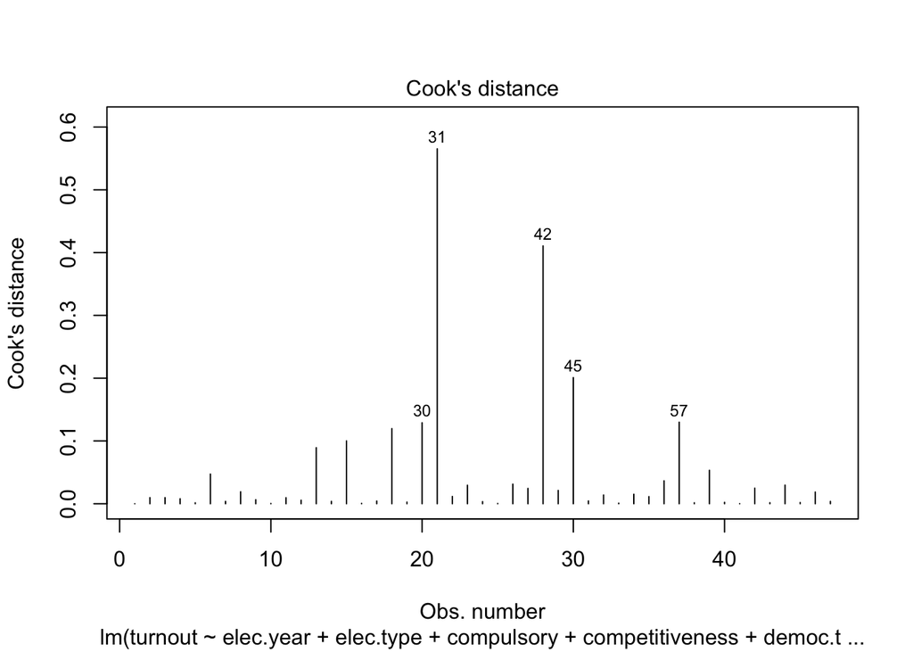

```r
plot(model, which = 4, id.n = 5)
```

## 5.3 A look at the outliers/influence points

```r
outliers <- c(31,42)
DT::datatable(Turnout[outliers,], options = list(scrollX = TRUE)) #don't include this line - this is just to visualize the table
```

|  | country | turnout | elec.year | compulsory | elec.type | democ.type | bicameral | DM | ENPP | competitiveness | years.democ | corrupt | educ | pop |
| --- | --- | --- | --- | --- | --- | --- | --- | --- | --- | --- | --- | --- | --- | --- |
| 31 | India | 59.73 | 1999 | No | Majoritarian | Parliamentary | Bicameral | 1 | 6.7 | 45.5 | 51 | 2.7 | 5.063 | 1014068 |
| 42 | Mali | 21.58 | 1997 | No | Majoritarian | Semi-Presidential | Unicameral | 2.67 | 1.59 | 35 | 8 | 3 | 0.876 | 10758.48 |

Two countries seem to be outliers:

- India, probably because of their insane population
- Mali, probably for low years of democracy

# 6 Concluding remarks

`corrupt`, `educ`, and `years.democ` all had an effect. You’re 3 for 3. But `years.democ` is opposite to what you predicted.

However, Canada is already doing well in all three of those aspects. Luckily, the multiple regression identified compulsory as a variable that highly affects voter turnout. Therefore, to increase Canadian voter turnout, Canada should throw scumbags who don’t vote (like Tony) in jail